# Risk Factor Analysis

## Outcome Variable

**Outcome Variable:** y_rate_len

## Predictor Variables

**Intervention Variable:** safeh20

**Adjustment Set:**

unadjusted

## Stratifying Variables

The analysis was stratified on these variable(s):

- agecat
- studyid
- country

## Data Summary

| agecat | studyid | country | safeh20 | n_cell | n |
| --- | --- | --- | --- | --- | --- |
| 0-3 months | CONTENT | PERU | 1 | 5 | 6 |
| 0-3 months | CONTENT | PERU | 0 | 1 | 6 |
| 0-3 months | JiVitA-3 | BANGLADESH | 1 | 19828 | 19862 |
| 0-3 months | JiVitA-3 | BANGLADESH | 0 | 34 | 19862 |
| 0-3 months | JiVitA-4 | BANGLADESH | 1 | 1805 | 1805 |
| 0-3 months | JiVitA-4 | BANGLADESH | 0 | 0 | 1805 |
| 0-3 months | MAL-ED | BANGLADESH | 1 | 0 | 236 |
| 0-3 months | MAL-ED | BANGLADESH | 0 | 236 | 236 |
| 0-3 months | MAL-ED | BRAZIL | 1 | 0 | 116 |
| 0-3 months | MAL-ED | BRAZIL | 0 | 116 | 116 |
| 0-3 months | MAL-ED | INDIA | 1 | 0 | 177 |
| 0-3 months | MAL-ED | INDIA | 0 | 177 | 177 |
| 0-3 months | MAL-ED | NEPAL | 1 | 1 | 153 |
| 0-3 months | MAL-ED | NEPAL | 0 | 152 | 153 |
| 0-3 months | MAL-ED | PERU | 1 | 11 | 243 |
| 0-3 months | MAL-ED | PERU | 0 | 232 | 243 |
| 0-3 months | MAL-ED | SOUTH AFRICA | 1 | 31 | 196 |
| 0-3 months | MAL-ED | SOUTH AFRICA | 0 | 165 | 196 |
| 0-3 months | MAL-ED | TANZANIA, UNITED REPUBLIC OF | 1 | 155 | 224 |
| 0-3 months | MAL-ED | TANZANIA, UNITED REPUBLIC OF | 0 | 69 | 224 |
| 0-3 months | NIH-Birth | BANGLADESH | 1 | 564 | 566 |
| 0-3 months | NIH-Birth | BANGLADESH | 0 | 2 | 566 |
| 0-3 months | NIH-Crypto | BANGLADESH | 1 | 721 | 721 |
| 0-3 months | NIH-Crypto | BANGLADESH | 0 | 0 | 721 |
| 0-3 months | PROVIDE | BANGLADESH | 1 | 13 | 13 |
| 0-3 months | PROVIDE | BANGLADESH | 0 | 0 | 13 |
| 3-6 months | CONTENT | PERU | 1 | 54 | 57 |
| 3-6 months | CONTENT | PERU | 0 | 3 | 57 |
| 3-6 months | JiVitA-3 | BANGLADESH | 1 | 12562 | 12574 |
| 3-6 months | JiVitA-3 | BANGLADESH | 0 | 12 | 12574 |

[output cut: 182 more lines]

The following strata were considered:

- agecat: 0-3 months, studyid: CONTENT, country: PERU
- agecat: 0-3 months, studyid: JiVitA-3, country: BANGLADESH
- agecat: 0-3 months, studyid: JiVitA-4, country: BANGLADESH
- agecat: 0-3 months, studyid: MAL-ED, country: BANGLADESH
- agecat: 0-3 months, studyid: MAL-ED, country: BRAZIL
- agecat: 0-3 months, studyid: MAL-ED, country: INDIA
- agecat: 0-3 months, studyid: MAL-ED, country: NEPAL
- agecat: 0-3 months, studyid: MAL-ED, country: PERU
- agecat: 0-3 months, studyid: MAL-ED, country: SOUTH AFRICA
- agecat: 0-3 months, studyid: MAL-ED, country: TANZANIA, UNITED REPUBLIC OF
- agecat: 0-3 months, studyid: NIH-Birth, country: BANGLADESH
- agecat: 0-3 months, studyid: NIH-Crypto, country: BANGLADESH
- agecat: 0-3 months, studyid: PROVIDE, country: BANGLADESH
- agecat: 12-15 months, studyid: CONTENT, country: PERU
- agecat: 12-15 months, studyid: JiVitA-4, country: BANGLADESH
- agecat: 12-15 months, studyid: LCNI-5, country: MALAWI
- agecat: 12-15 months, studyid: MAL-ED, country: BANGLADESH
- agecat: 12-15 months, studyid: MAL-ED, country: BRAZIL
- agecat: 12-15 months, studyid: MAL-ED, country: INDIA
- agecat: 12-15 months, studyid: MAL-ED, country: NEPAL
- agecat: 12-15 months, studyid: MAL-ED, country: PERU
- agecat: 12-15 months, studyid: MAL-ED, country: SOUTH AFRICA
- agecat: 12-15 months, studyid: MAL-ED, country: TANZANIA, UNITED REPUBLIC OF
- agecat: 12-15 months, studyid: NIH-Birth, country: BANGLADESH
- agecat: 12-15 months, studyid: NIH-Crypto, country: BANGLADESH
- agecat: 12-15 months, studyid: PROVIDE, country: BANGLADESH
- agecat: 12-15 months, studyid: SAS-FoodSuppl, country: INDIA
- agecat: 15-18 months, studyid: CONTENT, country: PERU
- agecat: 15-18 months, studyid: JiVitA-4, country: BANGLADESH
- agecat: 15-18 months, studyid: LCNI-5, country: MALAWI
- agecat: 15-18 months, studyid: MAL-ED, country: BANGLADESH
- agecat: 15-18 months, studyid: MAL-ED, country: BRAZIL
- agecat: 15-18 months, studyid: MAL-ED, country: INDIA
- agecat: 15-18 months, studyid: MAL-ED, country: NEPAL
- agecat: 15-18 months, studyid: MAL-ED, country: PERU
- agecat: 15-18 months, studyid: MAL-ED, country: SOUTH AFRICA
- agecat: 15-18 months, studyid: MAL-ED, country: TANZANIA, UNITED REPUBLIC OF
- agecat: 15-18 months, studyid: NIH-Birth, country: BANGLADESH
- agecat: 15-18 months, studyid: NIH-Crypto, country: BANGLADESH
- agecat: 15-18 months, studyid: PROVIDE, country: BANGLADESH
- agecat: 15-18 months, studyid: SAS-FoodSuppl, country: INDIA
- agecat: 18-21 months, studyid: CONTENT, country: PERU
- agecat: 18-21 months, studyid: LCNI-5, country: MALAWI
- agecat: 18-21 months, studyid: MAL-ED, country: BANGLADESH
- agecat: 18-21 months, studyid: MAL-ED, country: BRAZIL
- agecat: 18-21 months, studyid: MAL-ED, country: INDIA
- agecat: 18-21 months, studyid: MAL-ED, country: NEPAL
- agecat: 18-21 months, studyid: MAL-ED, country: PERU
- agecat: 18-21 months, studyid: MAL-ED, country: SOUTH AFRICA
- agecat: 18-21 months, studyid: MAL-ED, country: TANZANIA, UNITED REPUBLIC OF
- agecat: 18-21 months, studyid: NIH-Birth, country: BANGLADESH
- agecat: 18-21 months, studyid: NIH-Crypto, country: BANGLADESH
- agecat: 18-21 months, studyid: PROVIDE, country: BANGLADESH
- agecat: 21-24 months, studyid: CONTENT, country: PERU
- agecat: 21-24 months, studyid: LCNI-5, country: MALAWI
- agecat: 21-24 months, studyid: MAL-ED, country: BANGLADESH
- agecat: 21-24 months, studyid: MAL-ED, country: BRAZIL
- agecat: 21-24 months, studyid: MAL-ED, country: INDIA
- agecat: 21-24 months, studyid: MAL-ED, country: NEPAL
- agecat: 21-24 months, studyid: MAL-ED, country: PERU
- agecat: 21-24 months, studyid: MAL-ED, country: SOUTH AFRICA
- agecat: 21-24 months, studyid: MAL-ED, country: TANZANIA, UNITED REPUBLIC OF
- agecat: 21-24 months, studyid: NIH-Birth, country: BANGLADESH
- agecat: 21-24 months, studyid: NIH-Crypto, country: BANGLADESH
- agecat: 21-24 months, studyid: PROVIDE, country: BANGLADESH
- agecat: 3-6 months, studyid: CONTENT, country: PERU
- agecat: 3-6 months, studyid: JiVitA-3, country: BANGLADESH
- agecat: 3-6 months, studyid: JiVitA-4, country: BANGLADESH
- agecat: 3-6 months, studyid: MAL-ED, country: BANGLADESH
- agecat: 3-6 months, studyid: MAL-ED, country: BRAZIL
- agecat: 3-6 months, studyid: MAL-ED, country: INDIA
- agecat: 3-6 months, studyid: MAL-ED, country: NEPAL
- agecat: 3-6 months, studyid: MAL-ED, country: PERU
- agecat: 3-6 months, studyid: MAL-ED, country: SOUTH AFRICA
- agecat: 3-6 months, studyid: MAL-ED, country: TANZANIA, UNITED REPUBLIC OF
- agecat: 3-6 months, studyid: NIH-Birth, country: BANGLADESH
- agecat: 3-6 months, studyid: NIH-Crypto, country: BANGLADESH
- agecat: 3-6 months, studyid: PROVIDE, country: BANGLADESH
- agecat: 6-9 months, studyid: CONTENT, country: PERU
- agecat: 6-9 months, studyid: JiVitA-4, country: BANGLADESH
- agecat: 6-9 months, studyid: LCNI-5, country: MALAWI
- agecat: 6-9 months, studyid: MAL-ED, country: BANGLADESH
- agecat: 6-9 months, studyid: MAL-ED, country: BRAZIL
- agecat: 6-9 months, studyid: MAL-ED, country: INDIA
- agecat: 6-9 months, studyid: MAL-ED, country: NEPAL
- agecat: 6-9 months, studyid: MAL-ED, country: PERU
- agecat: 6-9 months, studyid: MAL-ED, country: SOUTH AFRICA
- agecat: 6-9 months, studyid: MAL-ED, country: TANZANIA, UNITED REPUBLIC OF
- agecat: 6-9 months, studyid: NIH-Birth, country: BANGLADESH
- agecat: 6-9 months, studyid: NIH-Crypto, country: BANGLADESH
- agecat: 6-9 months, studyid: PROVIDE, country: BANGLADESH
- agecat: 6-9 months, studyid: SAS-FoodSuppl, country: INDIA
- agecat: 9-12 months, studyid: CONTENT, country: PERU
- agecat: 9-12 months, studyid: JiVitA-4, country: BANGLADESH
- agecat: 9-12 months, studyid: LCNI-5, country: MALAWI
- agecat: 9-12 months, studyid: MAL-ED, country: BANGLADESH
- agecat: 9-12 months, studyid: MAL-ED, country: BRAZIL
- agecat: 9-12 months, studyid: MAL-ED, country: INDIA
- agecat: 9-12 months, studyid: MAL-ED, country: NEPAL
- agecat: 9-12 months, studyid: MAL-ED, country: PERU
- agecat: 9-12 months, studyid: MAL-ED, country: SOUTH AFRICA
- agecat: 9-12 months, studyid: MAL-ED, country: TANZANIA, UNITED REPUBLIC OF
- agecat: 9-12 months, studyid: NIH-Birth, country: BANGLADESH
- agecat: 9-12 months, studyid: NIH-Crypto, country: BANGLADESH
- agecat: 9-12 months, studyid: PROVIDE, country: BANGLADESH
- agecat: 9-12 months, studyid: SAS-FoodSuppl, country: INDIA

### Dropped Strata

Some strata were dropped due to rare outcomes:

- agecat: 0-3 months, studyid: CONTENT, country: PERU
- agecat: 0-3 months, studyid: JiVitA-4, country: BANGLADESH
- agecat: 0-3 months, studyid: MAL-ED, country: BANGLADESH
- agecat: 0-3 months, studyid: MAL-ED, country: BRAZIL
- agecat: 0-3 months, studyid: MAL-ED, country: INDIA
- agecat: 0-3 months, studyid: MAL-ED, country: NEPAL
- agecat: 0-3 months, studyid: NIH-Birth, country: BANGLADESH
- agecat: 0-3 months, studyid: NIH-Crypto, country: BANGLADESH
- agecat: 0-3 months, studyid: PROVIDE, country: BANGLADESH
- agecat: 3-6 months, studyid: CONTENT, country: PERU
- agecat: 3-6 months, studyid: JiVitA-4, country: BANGLADESH
- agecat: 3-6 months, studyid: MAL-ED, country: BANGLADESH
- agecat: 3-6 months, studyid: MAL-ED, country: BRAZIL
- agecat: 3-6 months, studyid: MAL-ED, country: INDIA
- agecat: 3-6 months, studyid: MAL-ED, country: NEPAL
- agecat: 3-6 months, studyid: NIH-Birth, country: BANGLADESH
- agecat: 3-6 months, studyid: NIH-Crypto, country: BANGLADESH
- agecat: 3-6 months, studyid: PROVIDE, country: BANGLADESH
- agecat: 6-9 months, studyid: CONTENT, country: PERU
- agecat: 6-9 months, studyid: JiVitA-4, country: BANGLADESH
- agecat: 6-9 months, studyid: MAL-ED, country: BANGLADESH
- agecat: 6-9 months, studyid: MAL-ED, country: BRAZIL
- agecat: 6-9 months, studyid: MAL-ED, country: INDIA
- agecat: 6-9 months, studyid: MAL-ED, country: NEPAL
- agecat: 6-9 months, studyid: NIH-Birth, country: BANGLADESH
- agecat: 6-9 months, studyid: NIH-Crypto, country: BANGLADESH
- agecat: 6-9 months, studyid: PROVIDE, country: BANGLADESH
- agecat: 6-9 months, studyid: SAS-FoodSuppl, country: INDIA
- agecat: 9-12 months, studyid: CONTENT, country: PERU
- agecat: 9-12 months, studyid: JiVitA-4, country: BANGLADESH
- agecat: 9-12 months, studyid: MAL-ED, country: BANGLADESH
- agecat: 9-12 months, studyid: MAL-ED, country: BRAZIL
- agecat: 9-12 months, studyid: MAL-ED, country: INDIA
- agecat: 9-12 months, studyid: MAL-ED, country: NEPAL
- agecat: 9-12 months, studyid: NIH-Birth, country: BANGLADESH
- agecat: 9-12 months, studyid: NIH-Crypto, country: BANGLADESH
- agecat: 9-12 months, studyid: PROVIDE, country: BANGLADESH
- agecat: 9-12 months, studyid: SAS-FoodSuppl, country: INDIA
- agecat: 12-15 months, studyid: CONTENT, country: PERU
- agecat: 12-15 months, studyid: JiVitA-4, country: BANGLADESH
- agecat: 12-15 months, studyid: MAL-ED, country: BANGLADESH
- agecat: 12-15 months, studyid: MAL-ED, country: BRAZIL
- agecat: 12-15 months, studyid: MAL-ED, country: INDIA
- agecat: 12-15 months, studyid: MAL-ED, country: NEPAL
- agecat: 12-15 months, studyid: NIH-Birth, country: BANGLADESH
- agecat: 12-15 months, studyid: NIH-Crypto, country: BANGLADESH
- agecat: 12-15 months, studyid: PROVIDE, country: BANGLADESH
- agecat: 12-15 months, studyid: SAS-FoodSuppl, country: INDIA
- agecat: 15-18 months, studyid: CONTENT, country: PERU
- agecat: 15-18 months, studyid: JiVitA-4, country: BANGLADESH
- agecat: 15-18 months, studyid: MAL-ED, country: BANGLADESH
- agecat: 15-18 months, studyid: MAL-ED, country: BRAZIL
- agecat: 15-18 months, studyid: MAL-ED, country: INDIA
- agecat: 15-18 months, studyid: MAL-ED, country: NEPAL
- agecat: 15-18 months, studyid: NIH-Birth, country: BANGLADESH
- agecat: 15-18 months, studyid: NIH-Crypto, country: BANGLADESH
- agecat: 15-18 months, studyid: PROVIDE, country: BANGLADESH
- agecat: 15-18 months, studyid: SAS-FoodSuppl, country: INDIA
- agecat: 18-21 months, studyid: CONTENT, country: PERU
- agecat: 18-21 months, studyid: MAL-ED, country: BANGLADESH
- agecat: 18-21 months, studyid: MAL-ED, country: BRAZIL
- agecat: 18-21 months, studyid: MAL-ED, country: INDIA
- agecat: 18-21 months, studyid: MAL-ED, country: NEPAL
- agecat: 18-21 months, studyid: NIH-Birth, country: BANGLADESH
- agecat: 18-21 months, studyid: NIH-Crypto, country: BANGLADESH
- agecat: 18-21 months, studyid: PROVIDE, country: BANGLADESH
- agecat: 21-24 months, studyid: CONTENT, country: PERU
- agecat: 21-24 months, studyid: MAL-ED, country: BANGLADESH
- agecat: 21-24 months, studyid: MAL-ED, country: BRAZIL
- agecat: 21-24 months, studyid: MAL-ED, country: INDIA
- agecat: 21-24 months, studyid: MAL-ED, country: NEPAL
- agecat: 21-24 months, studyid: NIH-Birth, country: BANGLADESH
- agecat: 21-24 months, studyid: NIH-Crypto, country: BANGLADESH
- agecat: 21-24 months, studyid: PROVIDE, country: BANGLADESH

## Methods Detail

We’re interested in the causal parameters $E[Y_a]$ for all values of $a \in \mathcal{A}$. These parameters represent the mean outcome if, possibly contrary to fact, we intervened to set all units to have $A=a$. Under the randomization and positivity assumptions, these are identified by the statistical parameters $\psi_a=E_W[E_{Y|A,W}(Y|A=a,W)]$. In addition, we’re interested in the mean of $Y$, $E[Y]$ under no intervention (the observed mean). We will estimate these parameters by using SuperLearner to fit the relevant likelihood factors – $E_{Y|A,W}(Y|A=a,W)$ and $p(A=a|W)$, and then updating our likelihood fit using a joint TMLE.

For unadjusted analyses ($W=\{\}$), initial likelihoods were estimated using Lrnr_glm to estimate the simple $E(Y|A)$ and Lrnr_mean to estimate $p(A)$. For adjusted analyses, a small library containing Lrnr_glmnet, Lrnr_xgboost, and Lrnr_mean was used.

Having estimated these parameters, we will then use the delta method to estimate relative risks and attributable risks relative to a prespecified baseline level of $A$.

# Results Detail

## Results Plots

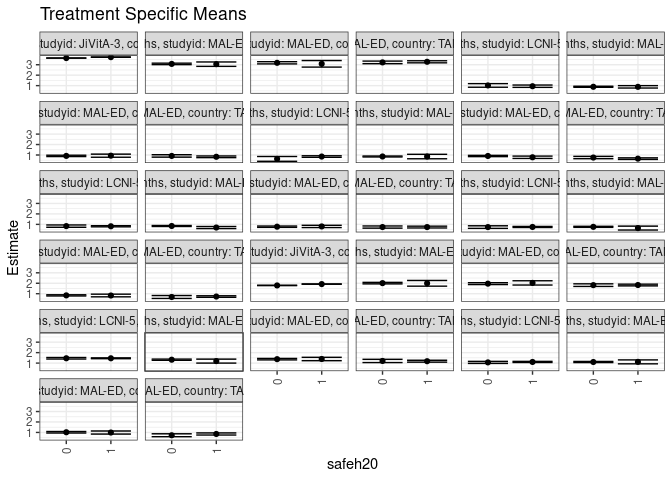

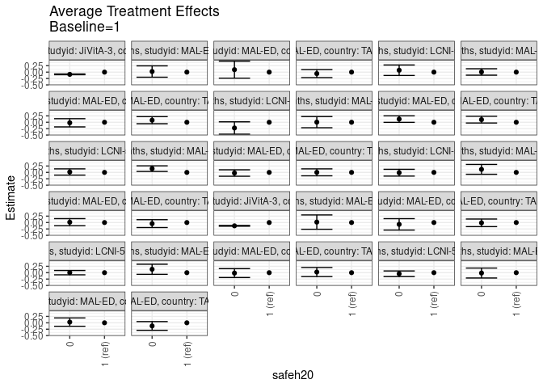

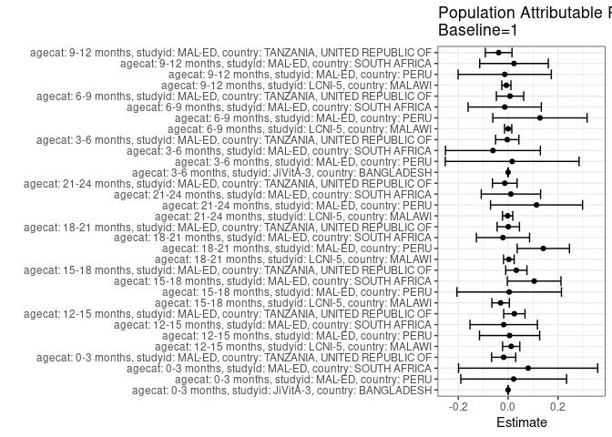

## Results Table

### Parameter: TSM

| agecat | studyid | country | intervention_level | baseline_level | estimate | ci_lower | ci_upper |
| --- | --- | --- | --- | --- | --- | --- | --- |
| 0-3 months | JiVitA-3 | BANGLADESH | 1 | NA | 3.7235622 | 3.7129947 | 3.7341296 |
| 0-3 months | JiVitA-3 | BANGLADESH | 0 | NA | 3.6362224 | 3.6264600 | 3.6459849 |
| 0-3 months | MAL-ED | PERU | 1 | NA | 3.0543487 | 2.8434291 | 3.2652683 |
| 0-3 months | MAL-ED | PERU | 0 | NA | 3.0777052 | 3.0082828 | 3.1471277 |
| 0-3 months | MAL-ED | SOUTH AFRICA | 1 | NA | 3.0867664 | 2.7724823 | 3.4010505 |
| 0-3 months | MAL-ED | SOUTH AFRICA | 0 | NA | 3.1821355 | 3.0766901 | 3.2875809 |
| 0-3 months | MAL-ED | TANZANIA, UNITED REPUBLIC OF | 1 | NA | 3.2810603 | 3.1828474 | 3.3792732 |
| 0-3 months | MAL-ED | TANZANIA, UNITED REPUBLIC OF | 0 | NA | 3.2230000 | 3.1007481 | 3.3452518 |
| 3-6 months | JiVitA-3 | BANGLADESH | 1 | NA | 1.9203196 | 1.9096087 | 1.9310305 |
| 3-6 months | JiVitA-3 | BANGLADESH | 0 | NA | 1.7917707 | 1.7822352 | 1.8013062 |
| 3-6 months | MAL-ED | PERU | 1 | NA | 1.9952084 | 1.7235889 | 2.2668279 |
| 3-6 months | MAL-ED | PERU | 0 | NA | 2.0121468 | 1.9423139 | 2.0819796 |
| 3-6 months | MAL-ED | SOUTH AFRICA | 1 | NA | 2.0345091 | 1.8285020 | 2.2405162 |
| 3-6 months | MAL-ED | SOUTH AFRICA | 0 | NA | 1.9627817 | 1.8750981 | 2.0504653 |
| 3-6 months | MAL-ED | TANZANIA, UNITED REPUBLIC OF | 1 | NA | 1.8322111 | 1.7508883 | 1.9135338 |
| 3-6 months | MAL-ED | TANZANIA, UNITED REPUBLIC OF | 0 | NA | 1.8207878 | 1.6966195 | 1.9449560 |
| 6-9 months | LCNI-5 | MALAWI | 1 | NA | 1.4587157 | 1.4174457 | 1.4999857 |
| 6-9 months | LCNI-5 | MALAWI | 0 | NA | 1.4600134 | 1.3855332 | 1.5344936 |
| 6-9 months | MAL-ED | PERU | 1 | NA | 1.1891673 | 1.0001965 | 1.3781382 |
| 6-9 months | MAL-ED | PERU | 0 | NA | 1.3225151 | 1.2654496 | 1.3795806 |
| 6-9 months | MAL-ED | SOUTH AFRICA | 1 | NA | 1.3905278 | 1.2313048 | 1.5497508 |
| 6-9 months | MAL-ED | SOUTH AFRICA | 0 | NA | 1.3744186 | 1.3040363 | 1.4448008 |
| 6-9 months | MAL-ED | TANZANIA, UNITED REPUBLIC OF | 1 | NA | 1.1791685 | 1.0900485 | 1.2682886 |
| 6-9 months | MAL-ED | TANZANIA, UNITED REPUBLIC OF | 0 | NA | 1.2040078 | 1.0502043 | 1.3578112 |
| 9-12 months | LCNI-5 | MALAWI | 1 | NA | 1.1078346 | 1.0550423 | 1.1606270 |
| 9-12 months | LCNI-5 | MALAWI | 0 | NA | 1.0656688 | 0.9697546 | 1.1615831 |
| 9-12 months | MAL-ED | PERU | 1 | NA | 1.1160877 | 0.9289289 | 1.3032464 |
| 9-12 months | MAL-ED | PERU | 0 | NA | 1.1019161 | 1.0482767 | 1.1555555 |
| 9-12 months | MAL-ED | SOUTH AFRICA | 1 | NA | 0.9911015 | 0.8441739 | 1.1380292 |
| 9-12 months | MAL-ED | SOUTH AFRICA | 0 | NA | 1.0191347 | 0.9468856 | 1.0913837 |
| 9-12 months | MAL-ED | TANZANIA, UNITED REPUBLIC OF | 1 | NA | 0.8535943 | 0.7543033 | 0.9528854 |
| 9-12 months | MAL-ED | TANZANIA, UNITED REPUBLIC OF | 0 | NA | 0.7307786 | 0.5913353 | 0.8702219 |
| 12-15 months | LCNI-5 | MALAWI | 1 | NA | 0.9455394 | 0.8350495 | 1.0560293 |
| 12-15 months | LCNI-5 | MALAWI | 0 | NA | 1.0193447 | 0.8465255 | 1.1921640 |
| 12-15 months | MAL-ED | PERU | 1 | NA | 0.8846595 | 0.7695897 | 0.9997294 |
| 12-15 months | MAL-ED | PERU | 0 | NA | 0.8907084 | 0.8410984 | 0.9403185 |
| 12-15 months | MAL-ED | SOUTH AFRICA | 1 | NA | 0.9349756 | 0.7869528 | 1.0829984 |
| 12-15 months | MAL-ED | SOUTH AFRICA | 0 | NA | 0.9139355 | 0.8512901 | 0.9765808 |
| 12-15 months | MAL-ED | TANZANIA, UNITED REPUBLIC OF | 1 | NA | 0.8292691 | 0.7516477 | 0.9068904 |
| 12-15 months | MAL-ED | TANZANIA, UNITED REPUBLIC OF | 0 | NA | 0.9106296 | 0.7959278 | 1.0253314 |
| 15-18 months | LCNI-5 | MALAWI | 1 | NA | 0.8529229 | 0.7802301 | 0.9256157 |
| 15-18 months | LCNI-5 | MALAWI | 0 | NA | 0.6287857 | 0.3993908 | 0.8581806 |
| 15-18 months | MAL-ED | PERU | 1 | NA | 0.8534728 | 0.6397559 | 1.0671898 |
| 15-18 months | MAL-ED | PERU | 0 | NA | 0.8578623 | 0.8135834 | 0.9021411 |
| 15-18 months | MAL-ED | SOUTH AFRICA | 1 | NA | 0.7828780 | 0.6699717 | 0.8957844 |
| 15-18 months | MAL-ED | SOUTH AFRICA | 0 | NA | 0.9067024 | 0.8480191 | 0.9653858 |
| 15-18 months | MAL-ED | TANZANIA, UNITED REPUBLIC OF | 1 | NA | 0.6533779 | 0.5799728 | 0.7267831 |
| 15-18 months | MAL-ED | TANZANIA, UNITED REPUBLIC OF | 0 | NA | 0.7564174 | 0.6469456 | 0.8658892 |
| 18-21 months | LCNI-5 | MALAWI | 1 | NA | 0.8169541 | 0.7656855 | 0.8682228 |
| 18-21 months | LCNI-5 | MALAWI | 0 | NA | 0.8332582 | 0.7226816 | 0.9438348 |
| 18-21 months | MAL-ED | PERU | 1 | NA | 0.6966493 | 0.5976815 | 0.7956172 |
| 18-21 months | MAL-ED | PERU | 0 | NA | 0.8438128 | 0.7975106 | 0.8901149 |
| 18-21 months | MAL-ED | SOUTH AFRICA | 1 | NA | 0.8017170 | 0.6930197 | 0.9104144 |
| 18-21 months | MAL-ED | SOUTH AFRICA | 0 | NA | 0.7774169 | 0.7146809 | 0.8401530 |
| 18-21 months | MAL-ED | TANZANIA, UNITED REPUBLIC OF | 1 | NA | 0.7407635 | 0.6537411 | 0.8277860 |
| 18-21 months | MAL-ED | TANZANIA, UNITED REPUBLIC OF | 0 | NA | 0.7426130 | 0.6383851 | 0.8468409 |
| 21-24 months | LCNI-5 | MALAWI | 1 | NA | 0.7524034 | 0.7033730 | 0.8014337 |
| 21-24 months | LCNI-5 | MALAWI | 0 | NA | 0.7401904 | 0.6173036 | 0.8630773 |
| 21-24 months | MAL-ED | PERU | 1 | NA | 0.6442119 | 0.4583975 | 0.8300263 |
| 21-24 months | MAL-ED | PERU | 0 | NA | 0.7627749 | 0.7144494 | 0.8111003 |
| 21-24 months | MAL-ED | SOUTH AFRICA | 1 | NA | 0.8282831 | 0.7009342 | 0.9556320 |
| 21-24 months | MAL-ED | SOUTH AFRICA | 0 | NA | 0.8414204 | 0.7849451 | 0.8978956 |
| 21-24 months | MAL-ED | TANZANIA, UNITED REPUBLIC OF | 1 | NA | 0.7309093 | 0.6612385 | 0.8005800 |
| 21-24 months | MAL-ED | TANZANIA, UNITED REPUBLIC OF | 0 | NA | 0.6889680 | 0.5512938 | 0.8266422 |

### Parameter: E(Y)

| agecat | studyid | country | intervention_level | baseline_level | estimate | ci_lower | ci_upper |
| --- | --- | --- | --- | --- | --- | --- | --- |
| 0-3 months | JiVitA-3 | BANGLADESH | NA | NA | 3.7234127 | 3.7131065 | 3.7337188 |
| 0-3 months | MAL-ED | PERU | NA | NA | 3.0766479 | 3.0096811 | 3.1436148 |
| 0-3 months | MAL-ED | SOUTH AFRICA | NA | NA | 3.1670516 | 3.0651964 | 3.2689068 |
| 0-3 months | MAL-ED | TANZANIA, UNITED REPUBLIC OF | NA | NA | 3.2631757 | 3.1854001 | 3.3409512 |
| 3-6 months | JiVitA-3 | BANGLADESH | NA | NA | 1.9201969 | 1.9097350 | 1.9306589 |
| 3-6 months | MAL-ED | PERU | NA | NA | 2.0114190 | 1.9435740 | 2.0792639 |
| 3-6 months | MAL-ED | SOUTH AFRICA | NA | NA | 1.9735408 | 1.8927925 | 2.0542892 |
| 3-6 months | MAL-ED | TANZANIA, UNITED REPUBLIC OF | NA | NA | 1.8286113 | 1.7605412 | 1.8966813 |
| 6-9 months | LCNI-5 | MALAWI | NA | NA | 1.4589363 | 1.4224162 | 1.4954563 |
| 6-9 months | MAL-ED | PERU | NA | NA | 1.3168407 | 1.2615074 | 1.3721740 |
| 6-9 months | MAL-ED | SOUTH AFRICA | NA | NA | 1.3769400 | 1.3125507 | 1.4413293 |
| 6-9 months | MAL-ED | TANZANIA, UNITED REPUBLIC OF | NA | NA | 1.1868199 | 1.1090396 | 1.2646002 |
| 9-12 months | LCNI-5 | MALAWI | NA | NA | 1.1007887 | 1.0539615 | 1.1476158 |
| 9-12 months | MAL-ED | PERU | NA | NA | 1.1024805 | 1.0504394 | 1.1545215 |
| 9-12 months | MAL-ED | SOUTH AFRICA | NA | NA | 1.0146639 | 0.9495597 | 1.0797680 |
| 9-12 months | MAL-ED | TANZANIA, UNITED REPUBLIC OF | NA | NA | 0.8155931 | 0.7342357 | 0.8969504 |
| 12-15 months | LCNI-5 | MALAWI | NA | NA | 0.9578403 | 0.8612449 | 1.0544357 |
| 12-15 months | MAL-ED | PERU | NA | NA | 0.8904833 | 0.8425275 | 0.9384392 |
| 12-15 months | MAL-ED | SOUTH AFRICA | NA | NA | 0.9172722 | 0.8595621 | 0.9749824 |
| 12-15 months | MAL-ED | TANZANIA, UNITED REPUBLIC OF | NA | NA | 0.8542196 | 0.7897390 | 0.9187003 |
| 15-18 months | LCNI-5 | MALAWI | NA | NA | 0.8227868 | 0.7513696 | 0.8942040 |
| 15-18 months | MAL-ED | PERU | NA | NA | 0.8576910 | 0.8143303 | 0.9010517 |
| 15-18 months | MAL-ED | SOUTH AFRICA | NA | NA | 0.8873549 | 0.8344616 | 0.9402481 |
| 15-18 months | MAL-ED | TANZANIA, UNITED REPUBLIC OF | NA | NA | 0.6862933 | 0.6249762 | 0.7476104 |
| 18-21 months | LCNI-5 | MALAWI | NA | NA | 0.8198090 | 0.7732927 | 0.8663254 |
| 18-21 months | MAL-ED | PERU | NA | NA | 0.8378061 | 0.7930237 | 0.8825886 |
| 18-21 months | MAL-ED | SOUTH AFRICA | NA | NA | 0.7810829 | 0.7253333 | 0.8368325 |
| 18-21 months | MAL-ED | TANZANIA, UNITED REPUBLIC OF | NA | NA | 0.7413740 | 0.6736807 | 0.8090672 |
| 21-24 months | LCNI-5 | MALAWI | NA | NA | 0.7505036 | 0.7048983 | 0.7961088 |
| 21-24 months | MAL-ED | PERU | NA | NA | 0.7582148 | 0.7110844 | 0.8053451 |
| 21-24 months | MAL-ED | SOUTH AFRICA | NA | NA | 0.8395115 | 0.7878135 | 0.8912095 |
| 21-24 months | MAL-ED | TANZANIA, UNITED REPUBLIC OF | NA | NA | 0.7174798 | 0.6527204 | 0.7822392 |

### Parameter: ATE

| agecat | studyid | country | intervention_level | baseline_level | estimate | ci_lower | ci_upper |
| --- | --- | --- | --- | --- | --- | --- | --- |
| 0-3 months | JiVitA-3 | BANGLADESH | 1 | 1 | 0.0000000 | 0.0000000 | 0.0000000 |
| 0-3 months | JiVitA-3 | BANGLADESH | 0 | 1 | -0.0873398 | -0.1016316 | -0.0730479 |
| 0-3 months | MAL-ED | PERU | 1 | 1 | 0.0000000 | 0.0000000 | 0.0000000 |
| 0-3 months | MAL-ED | PERU | 0 | 1 | 0.0233565 | -0.1986943 | 0.2454073 |
| 0-3 months | MAL-ED | SOUTH AFRICA | 1 | 1 | 0.0000000 | 0.0000000 | 0.0000000 |
| 0-3 months | MAL-ED | SOUTH AFRICA | 0 | 1 | 0.0953691 | -0.2361324 | 0.4268706 |
| 0-3 months | MAL-ED | TANZANIA, UNITED REPUBLIC OF | 1 | 1 | 0.0000000 | 0.0000000 | 0.0000000 |
| 0-3 months | MAL-ED | TANZANIA, UNITED REPUBLIC OF | 0 | 1 | -0.0580603 | -0.2148764 | 0.0987558 |
| 3-6 months | JiVitA-3 | BANGLADESH | 1 | 1 | 0.0000000 | 0.0000000 | 0.0000000 |
| 3-6 months | JiVitA-3 | BANGLADESH | 0 | 1 | -0.1285490 | -0.1423471 | -0.1147508 |
| 3-6 months | MAL-ED | PERU | 1 | 1 | 0.0000000 | 0.0000000 | 0.0000000 |
| 3-6 months | MAL-ED | PERU | 0 | 1 | 0.0169384 | -0.2635144 | 0.2973912 |
| 3-6 months | MAL-ED | SOUTH AFRICA | 1 | 1 | 0.0000000 | 0.0000000 | 0.0000000 |
| 3-6 months | MAL-ED | SOUTH AFRICA | 0 | 1 | -0.0717274 | -0.2956187 | 0.1521640 |
| 3-6 months | MAL-ED | TANZANIA, UNITED REPUBLIC OF | 1 | 1 | 0.0000000 | 0.0000000 | 0.0000000 |
| 3-6 months | MAL-ED | TANZANIA, UNITED REPUBLIC OF | 0 | 1 | -0.0114233 | -0.1598522 | 0.1370056 |
| 6-9 months | LCNI-5 | MALAWI | 1 | 1 | 0.0000000 | 0.0000000 | 0.0000000 |
| 6-9 months | LCNI-5 | MALAWI | 0 | 1 | 0.0012977 | -0.0838523 | 0.0864476 |
| 6-9 months | MAL-ED | PERU | 1 | 1 | 0.0000000 | 0.0000000 | 0.0000000 |
| 6-9 months | MAL-ED | PERU | 0 | 1 | 0.1333478 | -0.0640515 | 0.3307470 |
| 6-9 months | MAL-ED | SOUTH AFRICA | 1 | 1 | 0.0000000 | 0.0000000 | 0.0000000 |
| 6-9 months | MAL-ED | SOUTH AFRICA | 0 | 1 | -0.0161092 | -0.1901944 | 0.1579759 |
| 6-9 months | MAL-ED | TANZANIA, UNITED REPUBLIC OF | 1 | 1 | 0.0000000 | 0.0000000 | 0.0000000 |
| 6-9 months | MAL-ED | TANZANIA, UNITED REPUBLIC OF | 0 | 1 | 0.0248392 | -0.1529187 | 0.2025972 |
| 9-12 months | LCNI-5 | MALAWI | 1 | 1 | 0.0000000 | 0.0000000 | 0.0000000 |
| 9-12 months | LCNI-5 | MALAWI | 0 | 1 | -0.0421658 | -0.1516490 | 0.0673174 |
| 9-12 months | MAL-ED | PERU | 1 | 1 | 0.0000000 | 0.0000000 | 0.0000000 |
| 9-12 months | MAL-ED | PERU | 0 | 1 | -0.0141716 | -0.2088651 | 0.1805220 |
| 9-12 months | MAL-ED | SOUTH AFRICA | 1 | 1 | 0.0000000 | 0.0000000 | 0.0000000 |
| 9-12 months | MAL-ED | SOUTH AFRICA | 0 | 1 | 0.0280331 | -0.1356973 | 0.1917636 |
| 9-12 months | MAL-ED | TANZANIA, UNITED REPUBLIC OF | 1 | 1 | 0.0000000 | 0.0000000 | 0.0000000 |
| 9-12 months | MAL-ED | TANZANIA, UNITED REPUBLIC OF | 0 | 1 | -0.1228157 | -0.2939973 | 0.0483659 |
| 12-15 months | LCNI-5 | MALAWI | 1 | 1 | 0.0000000 | 0.0000000 | 0.0000000 |
| 12-15 months | LCNI-5 | MALAWI | 0 | 1 | 0.0738053 | -0.1313154 | 0.2789261 |
| 12-15 months | MAL-ED | PERU | 1 | 1 | 0.0000000 | 0.0000000 | 0.0000000 |
| 12-15 months | MAL-ED | PERU | 0 | 1 | 0.0060489 | -0.1192597 | 0.1313574 |
| 12-15 months | MAL-ED | SOUTH AFRICA | 1 | 1 | 0.0000000 | 0.0000000 | 0.0000000 |
| 12-15 months | MAL-ED | SOUTH AFRICA | 0 | 1 | -0.0210401 | -0.1817734 | 0.1396932 |
| 12-15 months | MAL-ED | TANZANIA, UNITED REPUBLIC OF | 1 | 1 | 0.0000000 | 0.0000000 | 0.0000000 |
| 12-15 months | MAL-ED | TANZANIA, UNITED REPUBLIC OF | 0 | 1 | 0.0813606 | -0.0571370 | 0.2198581 |
| 15-18 months | LCNI-5 | MALAWI | 1 | 1 | 0.0000000 | 0.0000000 | 0.0000000 |
| 15-18 months | LCNI-5 | MALAWI | 0 | 1 | -0.2241372 | -0.4647744 | 0.0165000 |
| 15-18 months | MAL-ED | PERU | 1 | 1 | 0.0000000 | 0.0000000 | 0.0000000 |
| 15-18 months | MAL-ED | PERU | 0 | 1 | 0.0043894 | -0.2138663 | 0.2226452 |
| 15-18 months | MAL-ED | SOUTH AFRICA | 1 | 1 | 0.0000000 | 0.0000000 | 0.0000000 |
| 15-18 months | MAL-ED | SOUTH AFRICA | 0 | 1 | 0.1238244 | -0.0034218 | 0.2510706 |
| 15-18 months | MAL-ED | TANZANIA, UNITED REPUBLIC OF | 1 | 1 | 0.0000000 | 0.0000000 | 0.0000000 |
| 15-18 months | MAL-ED | TANZANIA, UNITED REPUBLIC OF | 0 | 1 | 0.1030394 | -0.0287650 | 0.2348438 |
| 18-21 months | LCNI-5 | MALAWI | 1 | 1 | 0.0000000 | 0.0000000 | 0.0000000 |
| 18-21 months | LCNI-5 | MALAWI | 0 | 1 | 0.0163041 | -0.1055797 | 0.1381879 |
| 18-21 months | MAL-ED | PERU | 1 | 1 | 0.0000000 | 0.0000000 | 0.0000000 |
| 18-21 months | MAL-ED | PERU | 0 | 1 | 0.1471634 | 0.0378999 | 0.2564270 |
| 18-21 months | MAL-ED | SOUTH AFRICA | 1 | 1 | 0.0000000 | 0.0000000 | 0.0000000 |
| 18-21 months | MAL-ED | SOUTH AFRICA | 0 | 1 | -0.0243001 | -0.1498028 | 0.1012026 |
| 18-21 months | MAL-ED | TANZANIA, UNITED REPUBLIC OF | 1 | 1 | 0.0000000 | 0.0000000 | 0.0000000 |
| 18-21 months | MAL-ED | TANZANIA, UNITED REPUBLIC OF | 0 | 1 | 0.0018495 | -0.1339311 | 0.1376300 |
| 21-24 months | LCNI-5 | MALAWI | 1 | 1 | 0.0000000 | 0.0000000 | 0.0000000 |
| 21-24 months | LCNI-5 | MALAWI | 0 | 1 | -0.0122129 | -0.1445200 | 0.1200941 |
| 21-24 months | MAL-ED | PERU | 1 | 1 | 0.0000000 | 0.0000000 | 0.0000000 |
| 21-24 months | MAL-ED | PERU | 0 | 1 | 0.1185629 | -0.0734327 | 0.3105586 |
| 21-24 months | MAL-ED | SOUTH AFRICA | 1 | 1 | 0.0000000 | 0.0000000 | 0.0000000 |
| 21-24 months | MAL-ED | SOUTH AFRICA | 0 | 1 | 0.0131373 | -0.1261724 | 0.1524470 |
| 21-24 months | MAL-ED | TANZANIA, UNITED REPUBLIC OF | 1 | 1 | 0.0000000 | 0.0000000 | 0.0000000 |
| 21-24 months | MAL-ED | TANZANIA, UNITED REPUBLIC OF | 0 | 1 | -0.0419413 | -0.1962403 | 0.1123578 |

### Parameter: PAR

| agecat | studyid | country | intervention_level | baseline_level | estimate | ci_lower | ci_upper |
| --- | --- | --- | --- | --- | --- | --- | --- |
| 0-3 months | JiVitA-3 | BANGLADESH | 1 | NA | -0.0001495 | -0.0005067 | 0.0002077 |
| 0-3 months | MAL-ED | PERU | 1 | NA | 0.0222992 | -0.1897008 | 0.2342992 |
| 0-3 months | MAL-ED | SOUTH AFRICA | 1 | NA | 0.0802852 | -0.1988277 | 0.3593981 |
| 0-3 months | MAL-ED | TANZANIA, UNITED REPUBLIC OF | 1 | NA | -0.0178847 | -0.0663176 | 0.0305483 |
| 3-6 months | JiVitA-3 | BANGLADESH | 1 | NA | -0.0001227 | -0.0004781 | 0.0002327 |
| 3-6 months | MAL-ED | PERU | 1 | NA | 0.0162106 | -0.2521919 | 0.2846130 |
| 3-6 months | MAL-ED | SOUTH AFRICA | 1 | NA | -0.0609683 | -0.2513036 | 0.1293671 |
| 3-6 months | MAL-ED | TANZANIA, UNITED REPUBLIC OF | 1 | NA | -0.0035998 | -0.0503785 | 0.0431789 |
| 6-9 months | LCNI-5 | MALAWI | 1 | NA | 0.0002205 | -0.0142504 | 0.0146915 |
| 6-9 months | MAL-ED | PERU | 1 | NA | 0.1276734 | -0.0613573 | 0.3167041 |
| 6-9 months | MAL-ED | SOUTH AFRICA | 1 | NA | -0.0135878 | -0.1604268 | 0.1332512 |
| 6-9 months | MAL-ED | TANZANIA, UNITED REPUBLIC OF | 1 | NA | 0.0076514 | -0.0471251 | 0.0624279 |
| 9-12 months | LCNI-5 | MALAWI | 1 | NA | -0.0070460 | -0.0254087 | 0.0113167 |
| 9-12 months | MAL-ED | PERU | 1 | NA | -0.0136072 | -0.2005478 | 0.1733334 |
| 9-12 months | MAL-ED | SOUTH AFRICA | 1 | NA | 0.0235623 | -0.1140623 | 0.1611870 |
| 9-12 months | MAL-ED | TANZANIA, UNITED REPUBLIC OF | 1 | NA | -0.0380013 | -0.0914917 | 0.0154891 |
| 12-15 months | LCNI-5 | MALAWI | 1 | NA | 0.0123009 | -0.0222243 | 0.0468261 |
| 12-15 months | MAL-ED | PERU | 1 | NA | 0.0058238 | -0.1148222 | 0.1264698 |
| 12-15 months | MAL-ED | SOUTH AFRICA | 1 | NA | -0.0177033 | -0.1529496 | 0.1175429 |
| 12-15 months | MAL-ED | TANZANIA, UNITED REPUBLIC OF | 1 | NA | 0.0249506 | -0.0178052 | 0.0677064 |
| 15-18 months | LCNI-5 | MALAWI | 1 | NA | -0.0301361 | -0.0653092 | 0.0050370 |
| 15-18 months | MAL-ED | PERU | 1 | NA | 0.0042181 | -0.2055203 | 0.2139566 |
| 15-18 months | MAL-ED | SOUTH AFRICA | 1 | NA | 0.1044768 | -0.0030492 | 0.2120028 |
| 15-18 months | MAL-ED | TANZANIA, UNITED REPUBLIC OF | 1 | NA | 0.0329154 | -0.0096757 | 0.0755065 |
| 18-21 months | LCNI-5 | MALAWI | 1 | NA | 0.0028549 | -0.0184949 | 0.0242048 |
| 18-21 months | MAL-ED | PERU | 1 | NA | 0.1411568 | 0.0362733 | 0.2460402 |
| 18-21 months | MAL-ED | SOUTH AFRICA | 1 | NA | -0.0206341 | -0.1272091 | 0.0859408 |
| 18-21 months | MAL-ED | TANZANIA, UNITED REPUBLIC OF | 1 | NA | 0.0006104 | -0.0442040 | 0.0454249 |
| 21-24 months | LCNI-5 | MALAWI | 1 | NA | -0.0018998 | -0.0224854 | 0.0186858 |
| 21-24 months | MAL-ED | PERU | 1 | NA | 0.1140028 | -0.0706383 | 0.2986439 |
| 21-24 months | MAL-ED | SOUTH AFRICA | 1 | NA | 0.0112285 | -0.1078412 | 0.1302981 |
| 21-24 months | MAL-ED | TANZANIA, UNITED REPUBLIC OF | 1 | NA | -0.0134295 | -0.0629092 | 0.0360503 |